# Socioeconomics Factors Affecting Fire Related Hospitalizations

Mason Asato

12/11/2018

## Background of Fire

The fire that I am analyzing data from is the Witch Fire that occurred in the San Diego County from October 21st, 2007 through November 13th, 2007. This fire was the second largest wildfire of the 2007 California wildfire season after the Zaca Wildfire in Santa Barbara. The Witch Fire burned 197,990 acres (801 km2) alone and then merged with the Poomacha and McCoy Fires, where it burned 247,800 acres (1,003 km2) all together. The Witch–Poomacha Fire caused at least $1.3 billion (2007 USD) in insured damages alone, becoming the costliest wildfire of 2007. As of August 2018, the Witch Fire is the ninth-largest wildfire in modern California history, as well as the fifth-most destructive wildfire on record in California.

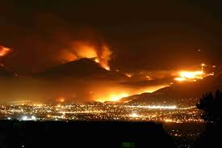

## Hospital Admission Data

[output not shown]

## Tri-City Medical Care

|  | Population (in 2016) | Land Area (sq mi.) | Population Density (people per sq mi.) | Zip Code Median Resident Age | State Median Resident Age | Average Adjusted Gross Income (AGI) | State Average Adjusted Gross Income (AGI) | Unemployment |
| --- | --- | --- | --- | --- | --- | --- | --- | --- |
| Tri City Medical Center | 34,358 | 3.8 | 9,123 | 39.5 | 36.4 | $84,695 | $72,726 | 3.80% |

## Scripps Mercy Hospital

[output not shown]

## Tri-City Medical Care Race Admission Data

Hospital admission data was analyzed from October 15th, 2007 through November 20th, 2007. Choosing these dates provided data one week prior to the fire and one week after the fire. I used an anova test to determine if there is a significant change in hospital admission data for the Hispanic population during the fire compared to the periods of time before and after the fire. These anova test results showed that there was a significant change in hospital admission data (F(2,34) = 3.344, p = .0472). The calculated p-value (0.0472) is smaller than 0.05 showing that there is a significant difference in Hispanic population data, during the fire compared to the periods before and after the fire. Through these results I can conclude that this test rejected my null hypothesis. I then used the same anova test to determine if there is a significant difference in hospital admission data for the White population during the fire and the periods before and after the fire. After anova test calculations, I determined that there was not a significant change in hospital admission data (F(2,34) = 0.333, p = .719). The calculated p-value (0.719) was larger than 0.05. As a result, the statistical tests agree with the null hypothesis.

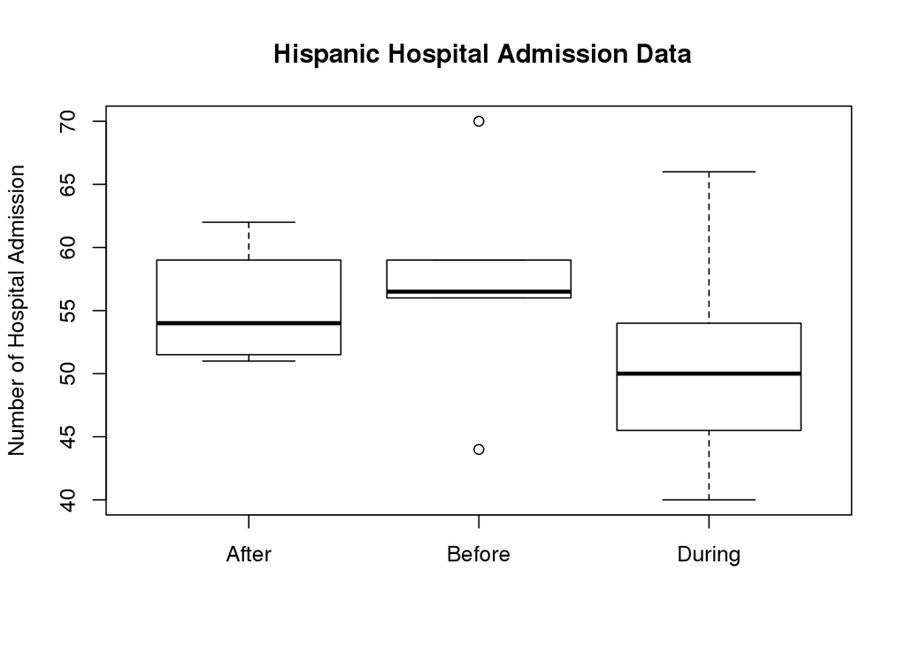

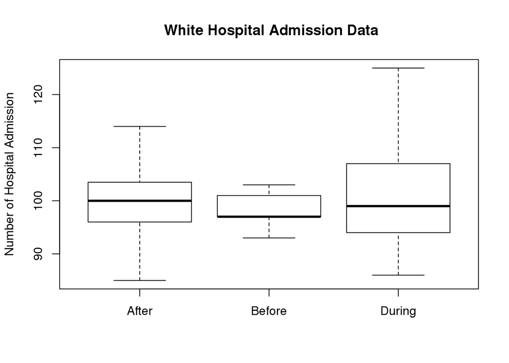

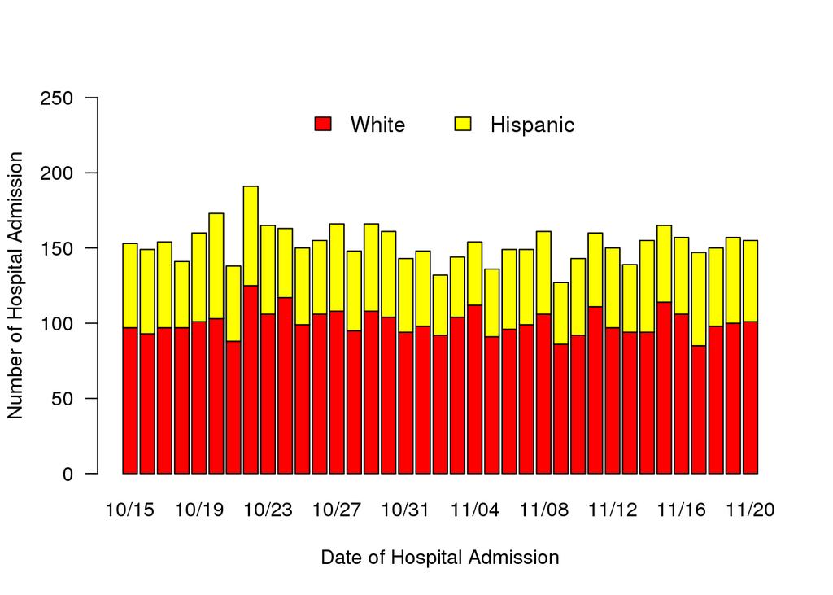

## Tri-City Medical Care Age Admission Data

I used a statistical chi-square test to determine if there is a significant change in hospital admission data at the Tri-City Medical Center for various age groups. A chi-square test allowed me to compare the total population percentages for each age group to the hospital admission percentage for that same age group. I did three trials of the chi-square test for three different periods, before, during and after the fire. I did not include dates where there are missing data in my calculations because since the number of hospital admission data for that category that day was less than 11 patients, the hospital did not record the data. After calculations, I determined that there was not a significant change in hospital admission data before the fire, X2 (3) = 0.56331, p =0.9048. When analyzing during the fire period, I found that there was no significant change in hospital admission data, X2 (3) = 0.7886, p =0.8522. Finally, when analyzing the after the fire period, I determined that there was also no significant change in hospital admission data, X2 (3) = 1.6536, p =0.6473.

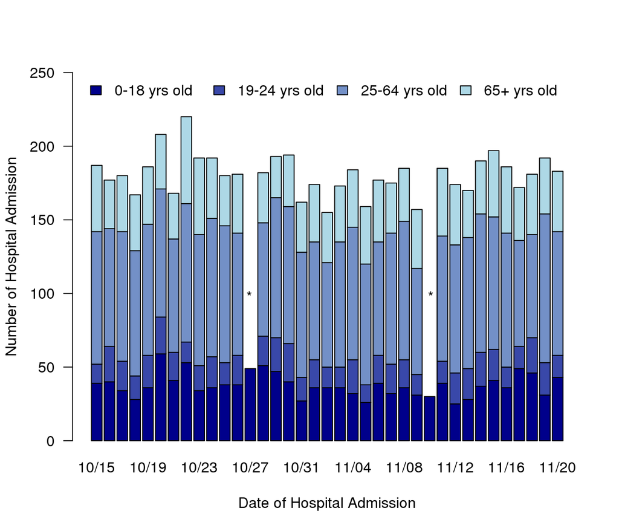

- = admission data < 11

## Tri-City Medical Care Respiratory Admission Data

This data set looks at the patients who were treated for respiratory issues. There is a similar trend to the rest of the data where there was a spike in the first couple days of the fire, then a decrease in patients and finally an increase again towards the end of the fire. I used a statistical t-test to determine if there is a significant change in respiratory hospital admission data during the fire compared to periods before and after the fire and determined that there was not a significant change in hospital admission data from ages 65+ years old. (t-test, t=0.81, df=29, p>0.05). I did not include dates where there are missing data in my calculations because since the number of hospital admission data for that category that day was less than 11 patients, the hospital did not record the data.

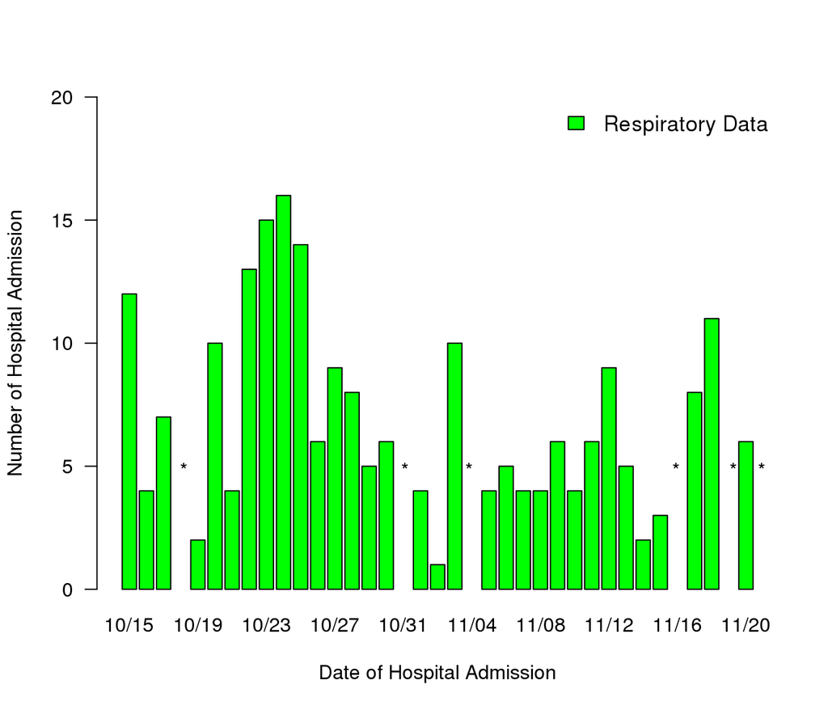

- = admission data < 11

## Scripps Mercy Hospital Race Admission Data

When analyzing the racial statistics of the Scripps Mercy Hospital admission data from October 15th, 2007 through November 20th, 2007, there was a similar spike of hospital admission data the second and third day of the fire, October 22nd and October 23rd, 2007. However, after that there was a mild decrease in hospital admission data. This trend was similar the Tri-City Medical Center hospital admission data. I used an anova test to determine if there is a significant change in hospital admission data for the Hispanic population during the fire compared to the periods of time before and after the fire. These anova test results showed that there was not a significant change in hospital admission data (F(2,34) = 1.147, p = .33). The calculated p-value (0.33) is large than 0.05 showing that there is a no significant difference in Hispanic population data, during the fire compared to the periods before and after the fire. Through these results I can conclude that this test agrees with my null hypothesis. I then used the same anova test to determine if there is a significant difference in hospital admission data for the White population during the fire and the periods before and after the fire. After anova test calculations, I determined that there was not a significant change in hospital admission data (F(2,34) = 1.432, p = .253). The calculated p-value (0.253) was larger than 0.05. As a result, the statistical tests agree with the null hypothesis.

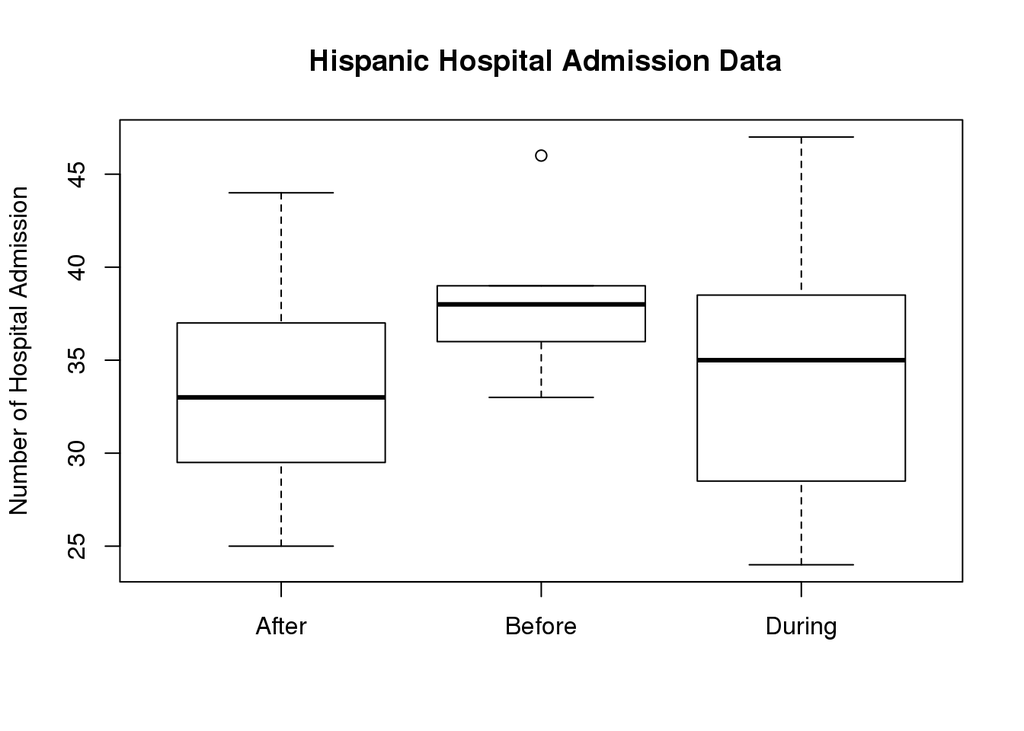

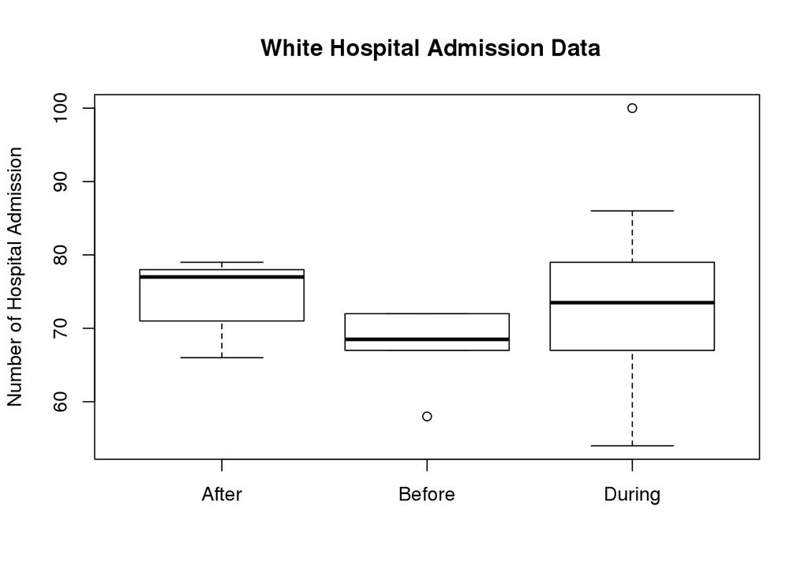

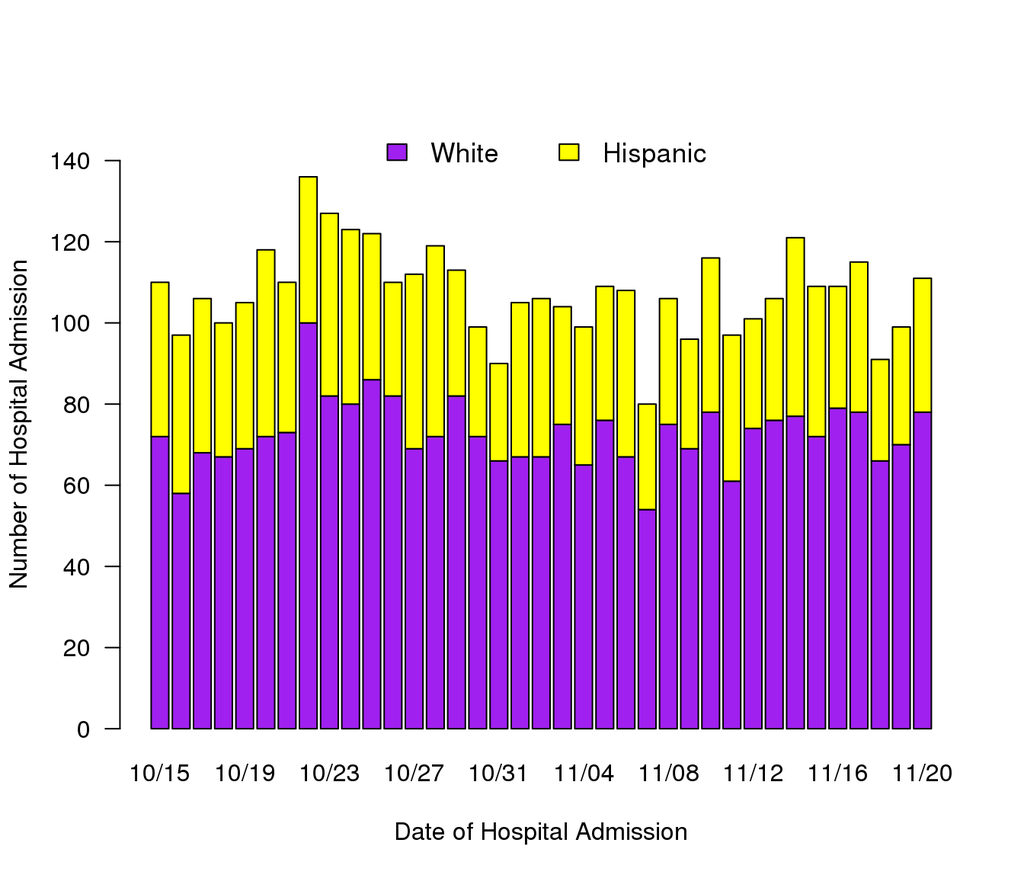

## Scripps Mercy Hospital Age Admission Data

When analyzing this there are lots of missing data but that is because when hospital admissions are less that 11 patients then it does not record that data for that category/day. However, inferring from this graph, there is an overall trend where there is a spike in the beginning days of the fire then a decrease and then again, another spike towards the end of the fire. I used a statistical chi-square test to determine if there is a significant change in hospital admission data at the Scripps Mercy Hospital for various age groups. A chi-square test allowed me to compare the total population percentages for each age group to the hospital admission percentage for that same age group. I did three trials of the chi-square test for three different periods, before, during and after the fire. I did not include dates where there are missing data in my calculations because since the number of hospital admission data for that category that day was less than 11 patients, the hospital did not record the data. After calculations, I determined that there was not a significant change in hospital admission data before the fire, X2 (3) = 3.8566, p =0.2774. When analyzing during the fire period, I found that there was no significant change in hospital admission data, X2 (3) = 4.7665, p =0.1897. Finally, when analyzing the after the fire period, I determined that there was also no significant change in hospital admission data, X2 (3) = 4.8044, p =0.1867.

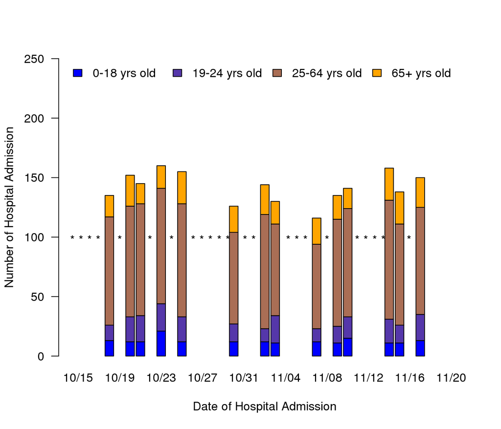

- = admission data < 11

## Scripps Mercy Hospital Respiratory Admission Data

Similar to the graph above, there are quite a few missing days because there were less than 11 respiratory patients for that day. However, when analyzing the data that we do have, we can clearly see that the fire caused an initial increase in respiratory patients, then it went down as the fire continued and then increased again at the end of the fire. I used a statistical t-test to determine if there is a significant change in respiratory hospital admission data during the fire compared to periods before and after the fire and determined that there was not a significant change in hospital admission data from ages 65+ years old. (t-test, t=1.7619, df=12 p>0.05). I did not include dates where there are missing data in my calculations because since the number of hospital admission data for that category that day was less than 11 patients, the hospital did not record the data.

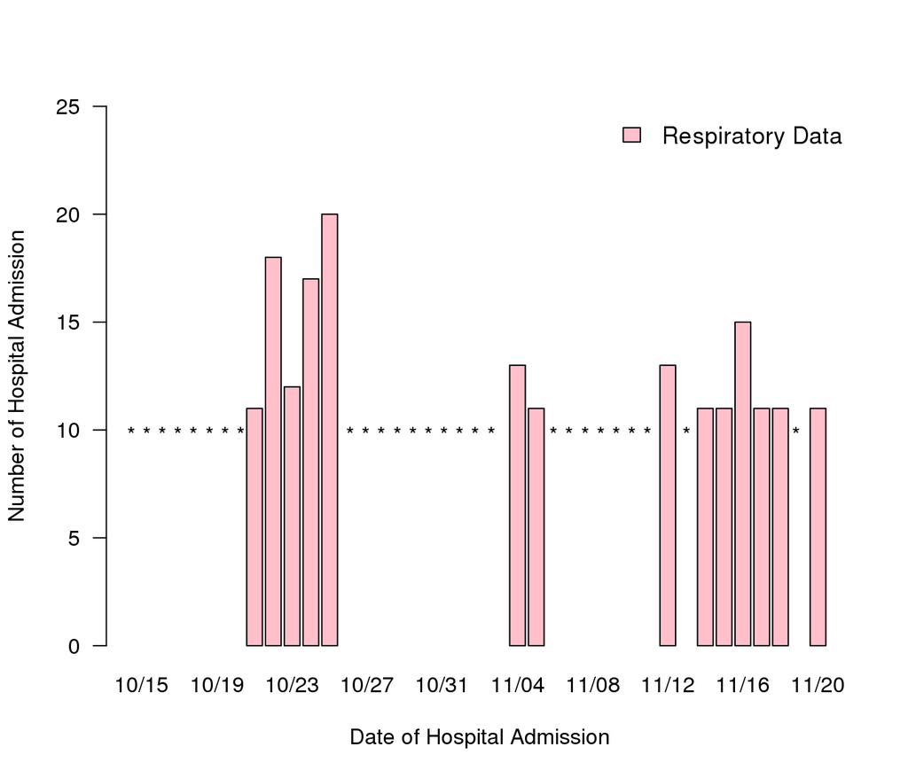

- = admission data < 11

## Is there a significant difference between age related Hospital Admissions before, during and after a fire period?

I used a chi-squared statistical test to compare my data between various age groups at both the Tri-City Medical Center and the Scripps Mercy Hospital. After calculations, I did not find a significant relationship between the admission demographics at the Tri-City Medical Center regarding the age composition of emergency department visits before, during and after the smoky period of a fire.

## Proposal

A recommendation to increase the accuracy of this experiment would be to get hospital admission data from a similar in size area that is not affected by the fire. This group would serve as the controlled group which would allow the studier to conduct a BACI test. The hospitals that are serving patients that have been affected by the fire would be the experimental group. A BACI test would allow the studier to have a base data to compare hospital admission data from the affected group.